# Sentiment, Topics, and Emotional Patterns in AI Startup Reviews

Salma Vikha Ainindita - DATA 407 Final Report

2026-04-06

# Load Libraries

```r
library(DBI)
library(RSQLite)
library(dplyr)
library(readr)
library(stringr)
library(tidyr)
library(ggplot2)
library(forcats)
library(scales)
```

# Preprocessing

```r
db_path <- "./dataset/reviews.sqlite"
doc_topics_path <- "./dataset/doc_topics_all_n30.csv"
topic_summaries_path <- "./dataset/openai_topic_summaries.csv"

con <- dbConnect(SQLite(), db_path)

reviews_df <- dbGetQuery(con, "
SELECT
    review_pk,
    review_id,
    startup_id,
    platform_id,
    title,
    content,
    rating_original,
    rating_scale_max,
    rating_norm01,
    review_date,
    language,
    country_code
FROM reviews
WHERE rating_original IS NOT NULL
")

vad_df <- dbGetQuery(con, "
SELECT
    review_pk,
    valence,
    arousal,
    low_confidence,
    coverage_review
FROM review_vad_dominant_polarity
")

startups_df <- dbGetQuery(con, "
SELECT
    startup_id,
    cluster
FROM startups
")

dbDisconnect(con)

doc_topics <- read_csv(doc_topics_path, show_col_types = FALSE)
topic_summaries <- read_csv(topic_summaries_path, show_col_types = FALSE)

topic_summaries_clean <- topic_summaries %>%
  mutate(
    clean_title = str_extract(summary, '(?<="title": ")[^"]+')
  ) %>%
  mutate(
    topic_title = ifelse(is.na(clean_title), paste("Topic", topic_id), clean_title)
  ) %>%
  select(topic_id, topic_title)

doc_topics_clean <- doc_topics %>%
  filter(topic_id != -1) %>%
  group_by(review_pk) %>%
  slice_max(order_by = probability, n = 1, with_ties = FALSE) %>%
  ungroup()

master_df <- reviews_df %>%
  left_join(vad_df, by = "review_pk") %>%
  left_join(doc_topics_clean, by = "review_pk") %>%
  left_join(topic_summaries_clean, by = "topic_id") %>%
  left_join(startups_df, by = "startup_id") %>%
  mutate(
    sentiment = case_when(
      rating_original < 3 ~ "negative",
      rating_original == 3 ~ "neutral",
      rating_original > 3 ~ "positive",
      TRUE ~ NA_character_
    ),
    sentiment = factor(sentiment, levels = c("negative", "neutral", "positive")),
    sentiment_score = case_when(
      sentiment == "negative" ~ -1,
      sentiment == "neutral" ~ 0,
      sentiment == "positive" ~ 1,
      TRUE ~ NA_real_
    ),
    is_positive = ifelse(sentiment == "positive", 1, 0),
    is_negative = ifelse(sentiment == "negative", 1, 0),
    is_neutral  = ifelse(sentiment == "neutral", 1, 0),
    extreme_rating = ifelse(rating_original %in% c(1, 5), 1, 0)
  )

cat("Rows in master dataset:", nrow(master_df), "\n")
```

```
## Rows in master dataset: 33169
```

```r
cat("Rows with non-missing topic:", sum(!is.na(master_df$topic_title)), "\n")
```

```
## Rows with non-missing topic: 28234
```

```r
cat("Rows with non-missing cluster:", sum(!is.na(master_df$cluster)), "\n")
```

```
## Rows with non-missing cluster: 33169
```

```r
cat("Rows with non-missing arousal:", sum(!is.na(master_df$arousal)), "\n")
```

```
## Rows with non-missing arousal: 32599
```

# Research Questions

1. **RQ1 (Sampling Bias in Reviews):** Does the overall positivity of AI reviews change after adjusting for startup-cluster imbalance?
2. **RQ2 (Topic Distribution and Satisfaction):** Do review topics vary across startup clusters, and are some topics associated with higher or lower satisfaction?
3. **RQ3 (Emotion Intensity vs Ratings):** Are extreme ratings (such as 1-star and 5-star reviews) associated with different arousal levels than non-extreme ratings?

# RQ1: Sampling Bias in Reviews

```r
rq1_df <- master_df %>%
  filter(!is.na(sentiment), !is.na(cluster)) %>%
  mutate(cluster = as.factor(cluster))

cat("Rows used for RQ1:", nrow(rq1_df), "\n")
```

```
## Rows used for RQ1: 33169
```

```r
cat("Clusters used:", n_distinct(rq1_df$cluster), "\n")
```

```
## Clusters used: 4
```

```r
naive_sentiment <- rq1_df %>%
  summarise(
    n = n(),
    positive_prop = mean(is_positive, na.rm = TRUE),
    negative_prop = mean(is_negative, na.rm = TRUE),
    neutral_prop  = mean(is_neutral, na.rm = TRUE)
  )

print(naive_sentiment)
```

```
##       n positive_prop negative_prop neutral_prop
## 1 33169     0.6061986      0.334077   0.05972444
```

```r
cluster_satisfaction <- rq1_df %>%
  group_by(cluster) %>%
  summarise(
    n = n(),
    mean_satisfaction = mean(sentiment_score, na.rm = TRUE),
    sd_satisfaction = sd(sentiment_score, na.rm = TRUE),
    se_satisfaction = sd_satisfaction / sqrt(n),
    positive_prop = mean(sentiment == "positive"),
    negative_prop = mean(sentiment == "negative"),
    neutral_prop = mean(sentiment == "neutral"),
    var_positive_h = var(is_positive, na.rm = TRUE),
    .groups = "drop"
  )

print(cluster_satisfaction)
```

```
## # A tibble: 4 × 9
##   cluster     n mean_satisfaction sd_satisfaction se_satisfaction positive_prop
##   <fct>   <int>             <dbl>           <dbl>           <dbl>         <dbl>
## 1 1       13050            0.0211           0.960         0.00841         0.472
## 2 2        9646            0.382            0.905         0.00921         0.673
## 3 3        1459            0.942            0.303         0.00794         0.960
## 4 4        9014            0.410            0.875         0.00922         0.672
## # ℹ 3 more variables: negative_prop <dbl>, neutral_prop <dbl>,
## #   var_positive_h <dbl>
```

```r
H <- n_distinct(cluster_satisfaction$cluster)

cluster_satisfaction <- cluster_satisfaction %>%
  mutate(W_h_equal = 1 / H)

positive_stratified <- sum(cluster_satisfaction$W_h_equal * cluster_satisfaction$positive_prop, na.rm = TRUE)
negative_stratified <- sum(cluster_satisfaction$W_h_equal * cluster_satisfaction$negative_prop, na.rm = TRUE)
neutral_stratified  <- sum(cluster_satisfaction$W_h_equal * cluster_satisfaction$neutral_prop, na.rm = TRUE)

comparison_df <- tibble(
  estimate_type = c("naive", "stratified_equal_weight"),
  positive_prop = c(naive_sentiment$positive_prop, positive_stratified),
  negative_prop = c(naive_sentiment$negative_prop, negative_stratified),
  neutral_prop  = c(naive_sentiment$neutral_prop, neutral_stratified)
)

print(comparison_df)
```

```
## # A tibble: 2 × 4
##   estimate_type           positive_prop negative_prop neutral_prop
##   <chr>                           <dbl>         <dbl>        <dbl>
## 1 naive                           0.606         0.334       0.0597
## 2 stratified_equal_weight         0.694         0.256       0.0501
```

```r
var_positive_stratified <- sum(
  (cluster_satisfaction$W_h_equal^2) *
    (cluster_satisfaction$var_positive_h / cluster_satisfaction$n),
  na.rm = TRUE
)

se_positive_stratified <- sqrt(var_positive_stratified)

stratified_precision <- tibble(
  estimate = "positive_prop",
  stratified_estimate = positive_stratified,
  stratified_se = se_positive_stratified,
  ci_lower = positive_stratified - 1.96 * se_positive_stratified,
  ci_upper = positive_stratified + 1.96 * se_positive_stratified
)

print(stratified_precision)
```

```
## # A tibble: 1 × 5
##   estimate      stratified_estimate stratified_se ci_lower ci_upper
##   <chr>                       <dbl>         <dbl>    <dbl>    <dbl>
## 1 positive_prop               0.694       0.00241    0.690    0.699
```

```r
bootstrap_compare <- function(data, B = 1000) {
  n_rows <- nrow(data)
  clusters <- unique(na.omit(data$cluster))
  H <- length(clusters)

  naive_vals <- numeric(B)
  strat_vals <- numeric(B)

  for (b in 1:B) {
    boot_data <- data %>% slice_sample(n = n_rows, replace = TRUE)

    naive_vals[b] <- mean(boot_data$is_positive, na.rm = TRUE)

    stratum_boot <- boot_data %>%
      filter(!is.na(cluster)) %>%
      group_by(cluster) %>%
      summarise(
        positive_h = mean(is_positive, na.rm = TRUE),
        .groups = "drop"
      )

    stratum_boot <- tibble(cluster = clusters) %>%
      left_join(stratum_boot, by = "cluster") %>%
      mutate(
        positive_h = ifelse(is.na(positive_h), 0, positive_h),
        W_h = 1 / H
      )

    strat_vals[b] <- sum(stratum_boot$W_h * stratum_boot$positive_h, na.rm = TRUE)
  }

  tibble(
    estimate_type = c("naive", "stratified_equal_weight"),
    mean_estimate = c(mean(naive_vals), mean(strat_vals)),
    ci_lower = c(quantile(naive_vals, 0.025), quantile(strat_vals, 0.025)),
    ci_upper = c(quantile(naive_vals, 0.975), quantile(strat_vals, 0.975))
  )
}

set.seed(123)
bootstrap_summary <- bootstrap_compare(rq1_df, B = 1000)
print(bootstrap_summary)
```

```
## # A tibble: 2 × 4
##   estimate_type           mean_estimate ci_lower ci_upper
##   <chr>                           <dbl>    <dbl>    <dbl>
## 1 naive                           0.606    0.601    0.612
## 2 stratified_equal_weight         0.694    0.690    0.699
```

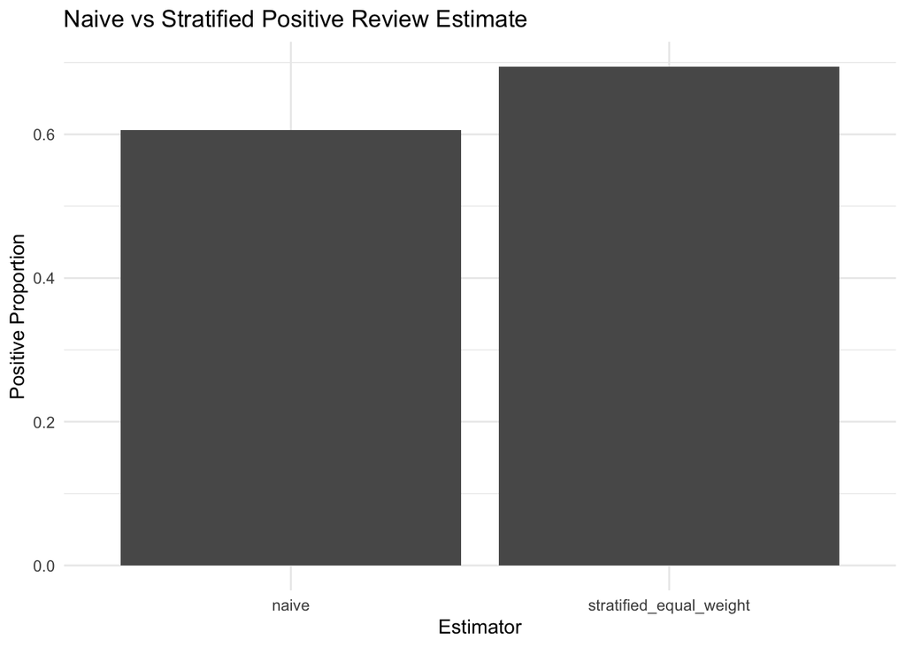

```r
ggplot(
  comparison_df,
  aes(x = estimate_type, y = positive_prop)
) +
  geom_col() +
  theme_minimal() +
  labs(
    title = "Naive vs Stratified Positive Review Estimate",
    x = "Estimator",
    y = "Positive Proportion"
  )
```

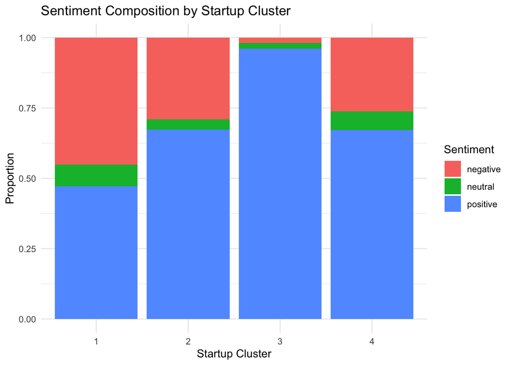

```r
cluster_sentiment_counts <- rq1_df %>%
  count(cluster, sentiment) %>%
  group_by(cluster) %>%
  mutate(prop = n / sum(n)) %>%
  ungroup()

ggplot(
  cluster_sentiment_counts,
  aes(x = cluster, y = prop, fill = sentiment)
) +
  geom_col() +
  theme_minimal() +
  labs(
    title = "Sentiment Composition by Startup Cluster",
    x = "Startup Cluster",
    y = "Proportion",
    fill = "Sentiment"
  )
```

## Conclusion

The naive estimate suggests that **60.6%** of reviews are positive, while the equal-weight stratified estimate suggests **69.4%**. The difference is **8.8%**. This shows that the overall positivity estimate changes depending on how startup clusters are weighted, so raw review summaries are sensitive to cluster imbalance.

# RQ2: Topic Distribution and Satisfaction

```r
rq2_df <- master_df %>%
  filter(!is.na(cluster), !is.na(topic_title), !is.na(sentiment), !is.na(sentiment_score)) %>%
  mutate(cluster = as.factor(cluster),
         topic_title = as.factor(topic_title))

cat("Rows used for RQ2:", nrow(rq2_df), "\n")
```

```
## Rows used for RQ2: 28234
```

```r
cat("Clusters used:", n_distinct(rq2_df$cluster), "\n")
```

```
## Clusters used: 4
```

```r
cat("Topics used:", n_distinct(rq2_df$topic_title), "\n")
```

```
## Topics used: 26
```

```r
topic_cluster_counts <- rq2_df %>%
  count(cluster, topic_title) %>%
  group_by(cluster) %>%
  mutate(
    cluster_total = sum(n),
    prop = n / cluster_total
  ) %>%
  ungroup()

print(topic_cluster_counts)
```

```
## # A tibble: 96 × 5
##    cluster topic_title                             n cluster_total     prop
##    <fct>   <fct>                               <int>         <int>    <dbl>
##  1 1       Account Management Issues             923         10547 0.0875
##  2 1       Collaborative Analytical Platforms      3         10547 0.000284
##  3 1       Concerns Over AI Guidance               8         10547 0.000759
##  4 1       Concerns Over Subscription Services   116         10547 0.0110
##  5 1       Consumer Complaints on Services       254         10547 0.0241
##  6 1       Conversational AI Experience          111         10547 0.0105
##  7 1       Customer Support Challenges            17         10547 0.00161
##  8 1       Exceptional Customer Support          305         10547 0.0289
##  9 1       Feedback on User Experience           166         10547 0.0157
## 10 1       Privacy Concerns and User Rights      177         10547 0.0168
## # ℹ 86 more rows
```

```r
topic_cluster_table <- rq2_df %>%
  count(cluster, topic_title) %>%
  tidyr::pivot_wider(
    names_from = topic_title,
    values_from = n,
    values_fill = 0
  )

topic_cluster_matrix <- topic_cluster_table %>%
  select(-cluster) %>%
  as.matrix()

chi_topic_cluster <- chisq.test(topic_cluster_matrix)
chi_topic_cluster
```

```
##
##  Pearson's Chi-squared test
##
## data:  topic_cluster_matrix
## X-squared = 54604, df = 75, p-value < 2.2e-16
```

```r
top_topics_by_cluster <- topic_cluster_counts %>%
  group_by(cluster) %>%
  slice_max(order_by = prop, n = 5, with_ties = FALSE) %>%
  ungroup()

print(top_topics_by_cluster)
```

```
## # A tibble: 20 × 5
##    cluster topic_title                                    n cluster_total   prop
##    <fct>   <fct>                                      <int>         <int>  <dbl>
##  1 1       User Experience Issues                      2937         10547 0.278
##  2 1       Subscription Service Concerns               2015         10547 0.191
##  3 1       User Experience Feedback                    1379         10547 0.131
##  4 1       User Experience Challenges                  1160         10547 0.110
##  5 1       Account Management Issues                    923         10547 0.0875
##  6 2       User Experience and Pricing Issues          3491          8696 0.401
##  7 2       Product Performance Issues                  1411          8696 0.162
##  8 2       User Experience with Free Tiers              930          8696 0.107
##  9 2       User Experience Feedback                     553          8696 0.0636
## 10 2       User Experience Challenges                   533          8696 0.0613
## 11 3       Collaborative Analytical Platforms           760          1435 0.530
## 12 3       Python Script Troubleshooting                284          1435 0.198
## 13 3       Concerns Over AI Guidance                    150          1435 0.105
## 14 3       Topic 27                                     113          1435 0.0787
## 15 3       User Experience with Transcription Servic…    70          1435 0.0488
## 16 4       Conversational AI Experience                1797          7556 0.238
## 17 4       Privacy Concerns and User Rights            1200          7556 0.159
## 18 4       Feedback on User Experience                 1181          7556 0.156
## 19 4       Topic 12                                     596          7556 0.0789
## 20 4       User Frustrations with AI Services           525          7556 0.0695
```

```r
bootstrap_mean_ci <- function(x, B = 1000) {
  x <- x[!is.na(x)]
  n <- length(x)
  vals <- numeric(B)

  for (b in 1:B) {
    vals[b] <- mean(sample(x, size = n, replace = TRUE))
  }

  tibble(
    mean_estimate = mean(vals),
    ci_lower = quantile(vals, 0.025),
    ci_upper = quantile(vals, 0.975)
  )
}

topic_satisfaction <- rq2_df %>%
  group_by(topic_title) %>%
  summarise(
    n = n(),
    mean_satisfaction = mean(sentiment_score, na.rm = TRUE),
    sd_satisfaction = sd(sentiment_score, na.rm = TRUE),
    se_satisfaction = sd_satisfaction / sqrt(n),
    positive_prop = mean(sentiment == "positive"),
    negative_prop = mean(sentiment == "negative"),
    neutral_prop = mean(sentiment == "neutral"),
    .groups = "drop"
  ) %>%
  arrange(desc(mean_satisfaction))

topic_satisfaction_boot <- rq2_df %>%
  group_by(topic_title) %>%
  summarise(
    out = list(bootstrap_mean_ci(sentiment_score, B = 1000)),
    .groups = "drop"
  ) %>%
  tidyr::unnest(out)

topic_satisfaction_final <- topic_satisfaction %>%
  left_join(
    topic_satisfaction_boot %>%
      select(topic_title, mean_estimate, ci_lower, ci_upper),
    by = "topic_title"
  )

print(topic_satisfaction_final)
```

```
## # A tibble: 26 × 11
##    topic_title               n mean_satisfaction sd_satisfaction se_satisfaction
##    <fct>                 <int>             <dbl>           <dbl>           <dbl>
##  1 Collaborative Analyt…   777             0.943           0.299         0.0107
##  2 Python Script Troubl…   301             0.924           0.352         0.0203
##  3 User-Friendly Testin…   208             0.913           0.396         0.0274
##  4 User Experience with…   541             0.900           0.405         0.0174
##  5 Topic 27                165             0.879           0.466         0.0363
##  6 User Experience and …  3581             0.841           0.528         0.00882
##  7 Concerns Over AI Gui…   168             0.833           0.544         0.0419
##  8 Exceptional Customer…   502             0.695           0.681         0.0304
##  9 Feedback on User Exp…  1380             0.654           0.740         0.0199
## 10 Topic 26                243             0.556           0.793         0.0508
## # ℹ 16 more rows
## # ℹ 6 more variables: positive_prop <dbl>, negative_prop <dbl>,
## #   neutral_prop <dbl>, mean_estimate <dbl>, ci_lower <dbl>, ci_upper <dbl>
```

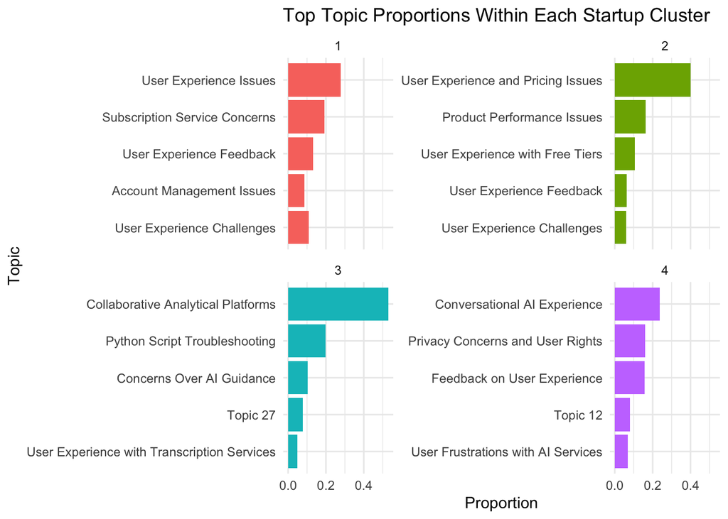

```r
ggplot(
  top_topics_by_cluster,
  aes(x = fct_reorder(topic_title, prop), y = prop, fill = cluster)
) +
  geom_col(show.legend = FALSE) +
  coord_flip() +
  facet_wrap(~ cluster, scales = "free_y") +
  theme_minimal() +
  labs(
    title = "Top Topic Proportions Within Each Startup Cluster",
    x = "Topic",
    y = "Proportion"
  )
```

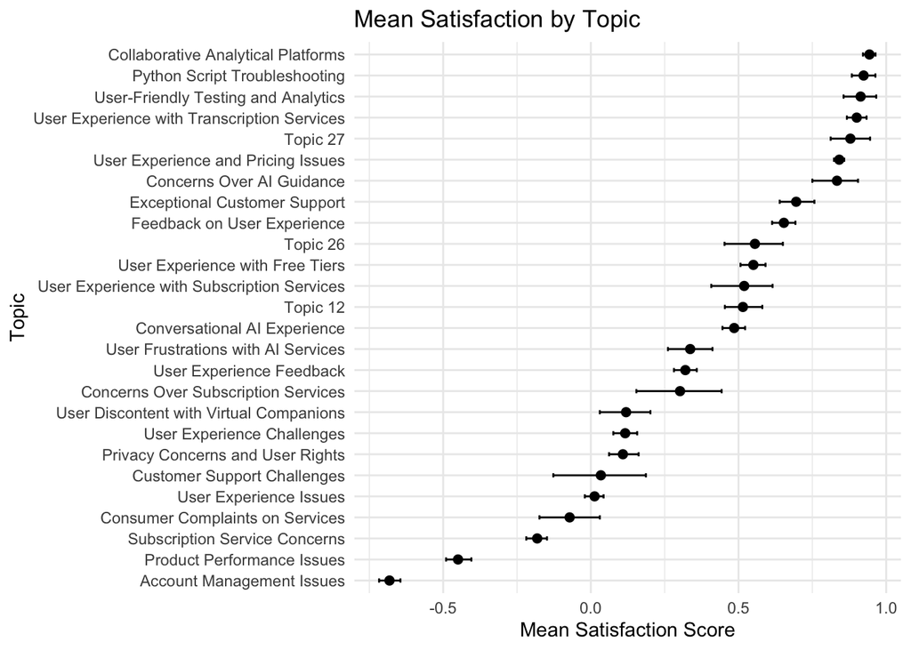

```r
ggplot(
  topic_satisfaction_final,
  aes(x = fct_reorder(topic_title, mean_satisfaction), y = mean_satisfaction)
) +
  geom_point(size = 2) +
  geom_errorbar(aes(ymin = ci_lower, ymax = ci_upper), width = 0.2) +
  coord_flip() +
  theme_minimal() +
  labs(
    title = "Mean Satisfaction by Topic",
    x = "Topic",
    y = "Mean Satisfaction Score"
  )
```

## Conclusion

The chi-square test comparing topic distributions across startup clusters gives a p-value of **<2e-16**. The topic with the highest mean satisfaction score is **Collaborative Analytical Platforms**, while the topic with the lowest mean satisfaction score is **Account Management Issues**. Together, these results show that startup clusters differ in the kinds of review topics they receive, and that review topics also differ meaningfully in their associated satisfaction levels.

# RQ3: Emotion Intensity vs Ratings

```r
rq3_df <- master_df %>%
  filter(!is.na(arousal), !is.na(rating_original), !is.na(extreme_rating))

cat("Rows used for RQ3:", nrow(rq3_df), "\n")
```

```
## Rows used for RQ3: 32599
```

```r
rq3_df_grouped <- rq3_df %>%
  mutate(
    rating_group = case_when(
      rating_original < 2 ~ "very low (< 2)",
      rating_original >= 2 & rating_original < 3 ~ "low [2, 3)",
      rating_original == 3 ~ "neutral (3)",
      rating_original > 3 & rating_original <= 4 ~ "high (3, 4]",
      rating_original > 4 ~ "very high (> 4)",
      TRUE ~ NA_character_
    ),
    rating_group = factor(
      rating_group,
      levels = c(
        "very low (< 2)",
        "low [2, 3)",
        "neutral (3)",
        "high (3, 4]",
        "very high (> 4)"
      )
    )
  ) %>%
  filter(!is.na(rating_group))
```

```r
rating_arousal_summary <- rq3_df_grouped %>%
  group_by(rating_group) %>%
  summarise(
    n = n(),
    mean_arousal = mean(arousal, na.rm = TRUE),
    sd_arousal = sd(arousal, na.rm = TRUE),
    se_arousal = sd_arousal / sqrt(n),
    .groups = "drop"
  )

print(rating_arousal_summary)
```

```
## # A tibble: 5 × 5
##   rating_group        n mean_arousal sd_arousal se_arousal
##   <fct>           <int>        <dbl>      <dbl>      <dbl>
## 1 very low (< 2)   8779       0.0124      0.285    0.00304
## 2 low [2, 3)       1961      -0.0263      0.268    0.00606
## 3 neutral (3)      1923      -0.0623      0.238    0.00543
## 4 high (3, 4]      3491      -0.0747      0.198    0.00334
## 5 very high (> 4) 16445      -0.0273      0.229    0.00178
```

```r
extreme_summary <- rq3_df %>%
  group_by(extreme_rating) %>%
  summarise(
    n = n(),
    mean_arousal = mean(arousal, na.rm = TRUE),
    sd_arousal = sd(arousal, na.rm = TRUE),
    se_arousal = sd_arousal / sqrt(n),
    .groups = "drop"
  ) %>%
  mutate(
    extreme_rating = ifelse(extreme_rating == 1, "extreme (1 or 5)", "non-extreme")
  )

print(extreme_summary)
```

```
## # A tibble: 2 × 5
##   extreme_rating       n mean_arousal sd_arousal se_arousal
##   <chr>            <int>        <dbl>      <dbl>      <dbl>
## 1 non-extreme       9038     -0.0634       0.217    0.00228
## 2 extreme (1 or 5) 23561     -0.00841      0.255    0.00166
```

```r
bootstrap_mean_diff <- function(data, B = 1000) {
  vals <- numeric(B)
  n_rows <- nrow(data)

  for (b in 1:B) {
    boot_data <- data %>% slice_sample(n = n_rows, replace = TRUE)

    mean_extreme <- mean(boot_data$arousal[boot_data$extreme_rating == 1], na.rm = TRUE)
    mean_non_extreme <- mean(boot_data$arousal[boot_data$extreme_rating == 0], na.rm = TRUE)

    vals[b] <- mean_extreme - mean_non_extreme
  }

  tibble(
    mean_difference = mean(vals, na.rm = TRUE),
    ci_lower = quantile(vals, 0.025, na.rm = TRUE),
    ci_upper = quantile(vals, 0.975, na.rm = TRUE)
  )
}

set.seed(123)
diff_boot <- bootstrap_mean_diff(rq3_df, B = 1000)
print(diff_boot)
```

```
## # A tibble: 1 × 3
##   mean_difference ci_lower ci_upper
##             <dbl>    <dbl>    <dbl>
## 1          0.0551   0.0496   0.0610
```

```r
t_test_result <- t.test(
  arousal ~ extreme_rating,
  data = rq3_df
)

t_test_result
```

```
##
##  Welch Two Sample t-test
##
## data:  arousal by extreme_rating
## t = -19.493, df = 19128, p-value < 2.2e-16
## alternative hypothesis: true difference in means between group 0 and group 1 is not equal to 0
## 95 percent confidence interval:
##  -0.06057201 -0.04950372
## sample estimates:
## mean in group 0 mean in group 1
##    -0.063444528    -0.008406666
```

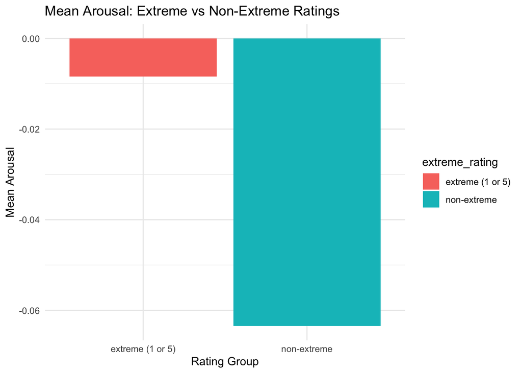

```r
ggplot(
  extreme_summary,
  aes(x = extreme_rating, y = mean_arousal, fill = extreme_rating)
) +
  geom_col() +
  theme_minimal() +
  labs(
    title = "Mean Arousal: Extreme vs Non-Extreme Ratings",
    x = "Rating Group",
    y = "Mean Arousal"
  )
```

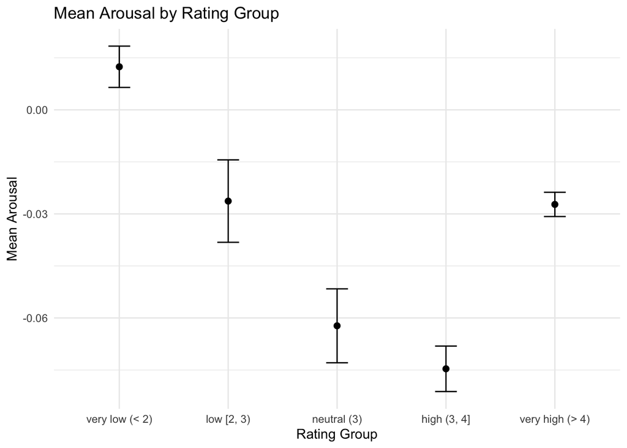

```r
ggplot(
  rating_arousal_summary,
  aes(x = rating_group, y = mean_arousal)
) +
  geom_point(size = 2) +
  geom_errorbar(
    aes(ymin = mean_arousal - 1.96 * se_arousal,
        ymax = mean_arousal + 1.96 * se_arousal),
    width = 0.2
  ) +
  theme_minimal() +
  labs(
    title = "Mean Arousal by Rating Group",
    x = "Rating Group",
    y = "Mean Arousal"
  )
```

## Conclusion

The mean arousal for extreme ratings (1 or 5) is **-0.008**, compared with **-0.063** for non-extreme ratings. The bootstrap estimate of the mean difference (extreme minus non-extreme) is **0.055**, with a 95% bootstrap confidence interval of **[0.05, 0.061]**. The two-sample t-test gives a p-value of **<2e-16**. Together, these results indicate a statistically supported difference in average arousal level between extreme and non-extreme ratings, although both means remain close to zero overall.

# Save Useful Outputs

```r
write_csv(master_df, "master_preprocessed_dataset.csv")

write_csv(rq1_df, "rq1_sampling_bias_dataset.csv")
write_csv(cluster_satisfaction, "rq1_cluster_satisfaction_summary.csv")
write_csv(comparison_df, "rq1_naive_vs_stratified.csv")
write_csv(bootstrap_summary, "rq1_bootstrap_summary.csv")

write_csv(rq2_df, "rq2_topic_distribution_satisfaction_dataset.csv")
write_csv(topic_cluster_counts, "rq2_topic_cluster_counts.csv")
write_csv(topic_satisfaction_final, "rq2_topic_satisfaction_summary.csv")
capture.output(chi_topic_cluster, file = "rq2_topic_cluster_chisq.txt")

write_csv(rq3_df, "rq3_emotion_intensity_ratings_dataset.csv")
write_csv(rating_arousal_summary, "rq3_rating_group_arousal_summary.csv")
write_csv(extreme_summary, "rq3_extreme_rating_summary.csv")
write_csv(diff_boot, "rq3_extreme_difference_bootstrap.csv")
capture.output(t_test_result, file = "rq3_t_test_result.txt")
```